# Hands-on exercise 6b: Visualising and Analysing Text Data with R: tidytext methods

Author

Andy Tai

Published

June 4, 2026

Modified

June 5, 2026

## 1 Overview

In this hands-on exercise, we will learn how to analyse and visualise text data using R.

By the end of this hands-on exercise, we will be able to:

- Understand the tidytext framework for processing, analysing, and visualising text data.
- Write functions to import multiple files into R.
- Merge multiple files into a single data frame.
- Clean and wrangle text data using the tidyverse approach.
- Create word clouds to visualise prominent terms.
- Compute Term Frequency–Inverse Document Frequency (TF-IDF) using the tidytext methodology.
- Visualise relationships among texts and terms.

## 2 Getting Started

In this hands-on lab, you will learn to manage, process, clean, analyze, and visualize textual data using the following R libraries:

- **Core Text & Data Wrangling**: tidytext, tidyverse (readr, purrr, stringr, ggplot2), lubridate, and hms
- **Text Relationships & Tables**: widyr and DT
- **Visualization & Graphing**: wordcloud, ggwordcloud, and textplot (along with its dependencies: igraph, tidygraph, and ggraph)

**(a) Install Libraries**

```r
pacman::p_load(tidytext, widyr, wordcloud, DT, ggwordcloud, textplot, lubridate, hms, tidyverse, tidygraph, ggraph, igraph)
```

**(b) Import data**

#### (i) Creating a folder list

```r
news20 <- "data/20news/"
```

#### (ii) Reading all files from a folder

As there are many files in the folder, we shall first create a function to read all the files from a folder into a dataframe.

**Step 1: Create a function to read all files**

```r
read_folder <- function(infolder) {
  tibble(file = dir(infolder,
                    full.names = TRUE)) %>%
    mutate(text = map(file,
                      read_lines)) %>%
    transmute(id = basename(file),
              text) %>%
    unnest(text)
}
```

**Step 2: Importing all messages**

Next, we implement the function and read in all the files in the folder.

```r
raw_text <- tibble(folder =
                     dir(news20,
                         full.names = TRUE)) %>%
  mutate(folder_out = map(folder,
                          read_folder)) %>%
  unnest(cols = c(folder_out)) %>%
  transmute(newsgroup = basename(folder),
            id, text)

dir.create("data/rds", recursive = TRUE, showWarnings = FALSE)
write_rds(raw_text, "data/rds/news20.rds")
```

**Note**

[figure not shown]

Points to Note

**Step 3: Initial EDA**

Figure below shows the frequency of messages by newsgroup.

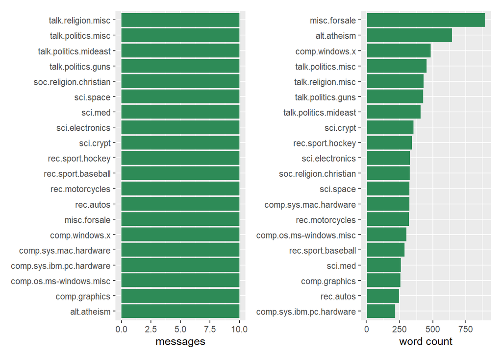

```r
library(patchwork)

## sort by number of messages
p1 <- raw_text %>%
  group_by(newsgroup) %>%
  summarize(messages = n_distinct(id)) %>%
  mutate(newsgroup = reorder(newsgroup, messages)) %>%
  ggplot(aes(messages, newsgroup)) +
  geom_col(fill = "seagreen") +
  labs(y = NULL)

## show word count
p2 <- raw_text %>%
  group_by(newsgroup) %>%
  summarize(words = n()) %>%
  mutate(newsgroup = reorder(newsgroup, words)) %>%
  ggplot(aes(words, newsgroup)) +
  geom_col(fill = "seagreen") +
  labs(y = NULL, x = "word count")

p1 + p2
```

## 3 Introducing tidytext

- Using tidy data principles in processing, analysing and visualising text data.
- Much of the infrastructure needed for text mining with tidy data frames already exists in packages like ‘dplyr’, ‘broom’, ‘tidyr’, and ‘ggplot2’.

**(a) Removing headers and automated email signatures**

- Irrelevant Text: Every message contains structural elements and extra text that need to be excluded from the analysis.
- Header Metadata: Each message has a header with descriptive fields (such as “from:” or “in_reply_to:”) that should be filtered out.
- Email Signatures: Automated signatures are often present at the bottom of the messages.
- Signature Marker: These signatures can be identified because they appear directly after a standard delimiter line (“–”).

```r
cleaned_text <- raw_text %>%
  group_by(newsgroup, id) %>%
  filter(cumsum(text == "") > 0,
         cumsum(str_detect(
           text, "^--")) == 0) %>%
  ungroup()
```

**Note**

Points to Note

- [cumsum()](https://rdrr.io/r/base/cumsum.html) of base R is used to return a vector whose elements are the cumulative sums of the elements of the argument.
- [str_detect()](https://stringr.tidyverse.org/reference/str_detect.html) from stringr is used to detect the presence or absence of a pattern in a string.

**(b) Removing lines with quotes**

In this code chunk below, regular expressions are used to remove with nested text representing quotes from other users.

```r
cleaned_text <- cleaned_text %>%
  filter(str_detect(text, "^[^>]+[A-Za-z\\d]")
         | text == "",
         !str_detect(text,
                     "writes(:|\\.\\.\\.)$"),
         !str_detect(text,
                     "^In article <")
  )
```

**Note**

Points to Note

- [str_detect()](https://stringr.tidyverse.org/reference/str_detect.html) from **stringr** is used to detect the presence or absence of a pattern in a string.
- [filter()](https://dplyr.tidyverse.org/reference/filter.html) of **dplyr** package is used to subset a data frame, retaining all rows that satisfy the specified conditions.

**(c) Textual Data processing**

In this code chunk below, [unnest_tokens()](https://www.rdocumentation.org/packages/tidytext/versions/0.3.1/topics/unnest_tokens) of **tidytext** package is used to split the dataset into tokens, while [stop_words()](https://rdrr.io/cran/tidytext/man/stop_words.html) is used to remove stop-words.

```r
usenet_words <- cleaned_text %>%
  unnest_tokens(word, text) %>%
  filter(str_detect(word, "[a-z']$"),
         !word %in% stop_words$word)
```

Now that we’ve removed the headers, signatures, and formatting, we can start exploring common words. For starters, we could find the most common words in the entire dataset, or within particular newsgroups.

```r
usenet_words %>%
  count(word, sort = TRUE)
```

```
# A tibble: 5,542 × 2
   word           n
   <chr>      <int>
 1 people        57
 2 time          50
 3 jesus         47
 4 god           44
 5 message       40
 6 br            27
 7 bible         23
 8 drive         23
 9 homosexual    23
10 read          22
# ℹ 5,532 more rows
```

Instead of counting individual word, we can also count words within by newsgroup by using the code chunk below.

```r
words_by_newsgroup <- usenet_words %>%
  count(newsgroup, word, sort = TRUE) %>%
  ungroup()
```

**(d) Word Clouds**

**(i) basic word cloud**

In this code chunk below, `wordcloud()` of **wordcloud package** is used to plot a static wordcloud, including a data table for information discovery.

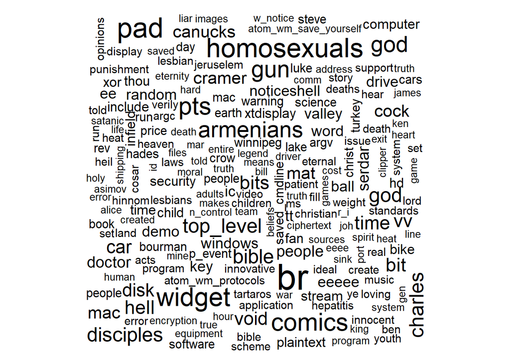

```r
wordcloud(words_by_newsgroup$word,
          words_by_newsgroup$n,
          max.words = 300)
```

```r
# Interactive data table
datatable(words_by_newsgroup,
          filter = "top",
          options = list(pageLength = 10,
                         scrollX = TRUE))
```

|  | newsgroup | word | n |
| --- | --- | --- | --- |
| 1 | alt.atheism | jesus | 39 |
| 2 | sci.crypt | message | 31 |
| 3 | alt.atheism | br | 27 |
| 4 | alt.atheism | rh | 21 |
| 5 | sci.crypt | pad | 20 |
| 6 | talk.politics.misc | homosexual | 20 |
| 7 | talk.politics.misc | homosexuals | 19 |
| 8 | comp.windows.x | widget | 18 |
| 9 | misc.forsale | comics | 17 |
| 10 | rec.sport.hockey | pts | 17 |

[output cut: 8114 more lines]

**(ii) ggwordcloud**

The wordcloud below is plotted by using [ggwordcloud](https://lepennec.github.io/ggwordcloud/) package.

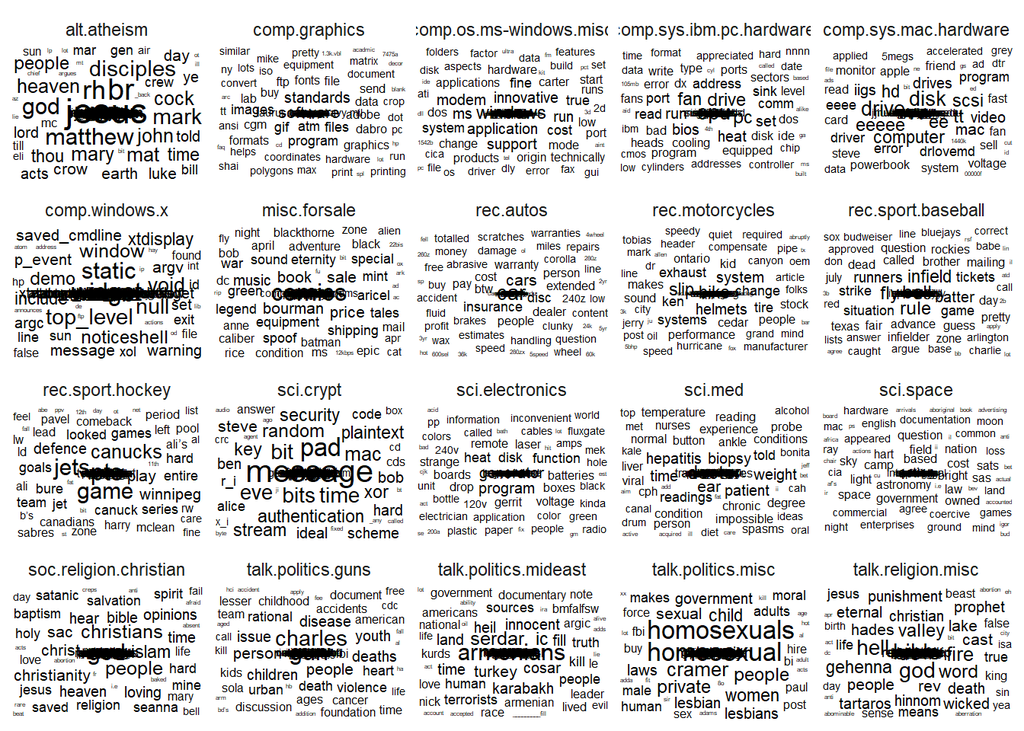

```r
set.seed(1234)

words_by_newsgroup %>%
  filter(n > 0) %>%
ggplot(aes(label = word,
           size = n)) +
  geom_text_wordcloud() +
  theme_minimal() +
  facet_wrap(~newsgroup)
```

## 4 Basic Concept of TF-IDF

- [tf–idf](https://en.wikipedia.org/wiki/Tf%E2%80%93idf), short for term frequency–inverse document frequency, is a numerical statistic that is intended to reflect how important a word is to a document in a collection of corpus.

$$idf(\text{term}) = \ln \left( \frac{n_{\text{documents}}}{n_{\text{documents containing term}}} \right)$$

**(a) computing TF-IDF**

The code chunk below uses bind_tf_idf() of tidytext to compute and bind the term frequency, inverse document frequency and ti-idf of a tidy text dataset to the dataset.

```r
tf_idf <- words_by_newsgroup %>%
  bind_tf_idf(word, newsgroup, n) %>%
  arrange(desc(tf_idf))
```

**(b) interactive table**

Table below is an interactive table created by using `datatable()`. This is created using the below code chunk that creates a html table that allows pagination of rows and columns.

```r
DT::datatable(tf_idf, filter = 'top') %>%
  formatRound(columns = c('tf', 'idf',
                          'tf_idf'),
              digits = 3) %>%
  formatStyle(0,
              target = 'row',
              lineHeight='25%')
```

|  | newsgroup | word | n | tf | idf | tf_idf |
| --- | --- | --- | --- | --- | --- | --- |
| 1 | rec.autos | car | 11 | 0.04150943396226415 | 2.302585092994046 | 0.0955790038601302 |
| 2 | sci.crypt | pad | 20 | 0.03115264797507788 | 2.995732273553991 | 0.09332499294560719 |
| 3 | comp.sys.ibm.pc.hardware | cpu | 11 | 0.03005464480874317 | 2.995732273553991 | 0.09003566942375382 |
| 4 | rec.sport.hockey | pts | 17 | 0.02698412698412699 | 2.995732273553991 | 0.08083722008002833 |
| 5 | talk.politics.misc | homosexuals | 19 | 0.02613480055020633 | 2.995732273553991 | 0.07829286547114969 |
| 6 | sci.crypt | message | 31 | 0.04828660436137071 | 1.6094379124341 | 0.07771429172189581 |
| 7 | comp.windows.x | widget | 18 | 0.02593659942363112 | 2.995732273553991 | 0.0776991079596136 |
| 8 | comp.sys.mac.hardware | vv | 12 | 0.02330097087378641 | 2.995732273553991 | 0.06980347045174348 |
| 9 | talk.politics.guns | charles | 13 | 0.02268760907504363 | 2.995732273553991 | 0.0679660027158846 |
| 10 | comp.windows.x | static | 15 | 0.02161383285302594 | 2.995732273553991 | 0.06474925663301133 |

[output cut: 8114 more lines]

**Note**

Points to Note

- `filter()` argument is used to turn control the filter UI.
- `formatRound()` is used to customise the values format. The argument digits define the number of decimal places.
- `formatStyle()` is used to customise the output table. In this example, the arguments target and lineHeight are used to reduce the line height by 25%.

**(c) facted bar charts**

Facet bar charts technique is used to visualise the tf-idf values of science related newsgroup.

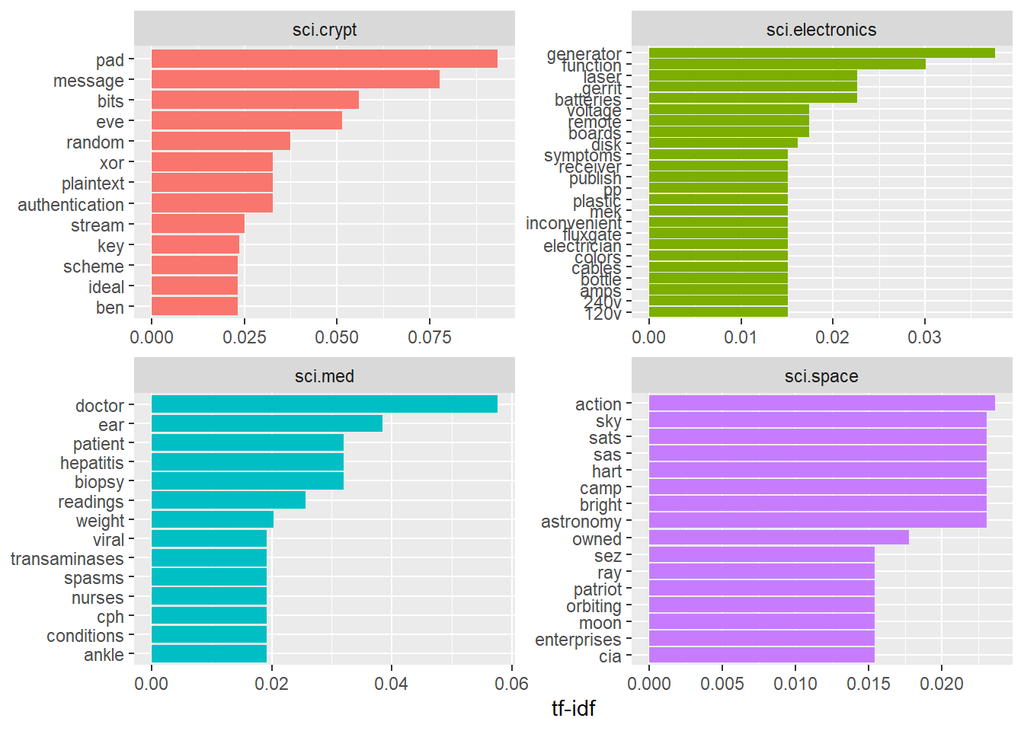

```r
tf_idf %>%
  filter(str_detect(newsgroup, "^sci\\.")) %>%
  group_by(newsgroup) %>%
  slice_max(tf_idf,
            n = 12) %>%
  ungroup() %>%
  mutate(word = reorder(word,
                        tf_idf)) %>%
  ggplot(aes(tf_idf,
             word,
             fill = newsgroup)) +
  geom_col(show.legend = FALSE) +
  facet_wrap(~ newsgroup,
             scales = "free") +
  labs(x = "tf-idf",
       y = NULL)
```

## 5 Counting and Correlating Pairs of Words

- **Goal**: Calculate how often two words appear together in the same document (pairwise counts) or determine their correlation.
- **The Matrix Problem**: Most tools require reshaping tidy data into a wide matrix to perform these pairwise calculations.
- **The widyr Solution**: The [widyr](https://cran.r-project.org/web/packages/widyr/index.html) package streamlines this workflow behind the scenes by temporarily casting tidy data into a wide matrix, running the operation (like correlation), and immediately re-tidying the results.

**(a) widyr package**

In this code chunk below, pairwise_cor() of widyr package is used to compute the correlation between newsgroup based on the common words found.

```r
newsgroup_cors <- words_by_newsgroup %>%
  pairwise_cor(newsgroup,
               word,
               n,
               sort = TRUE)
```

**(b) visualising correlation**

We can visualise the relationship between newgroups in network graph as shown below.

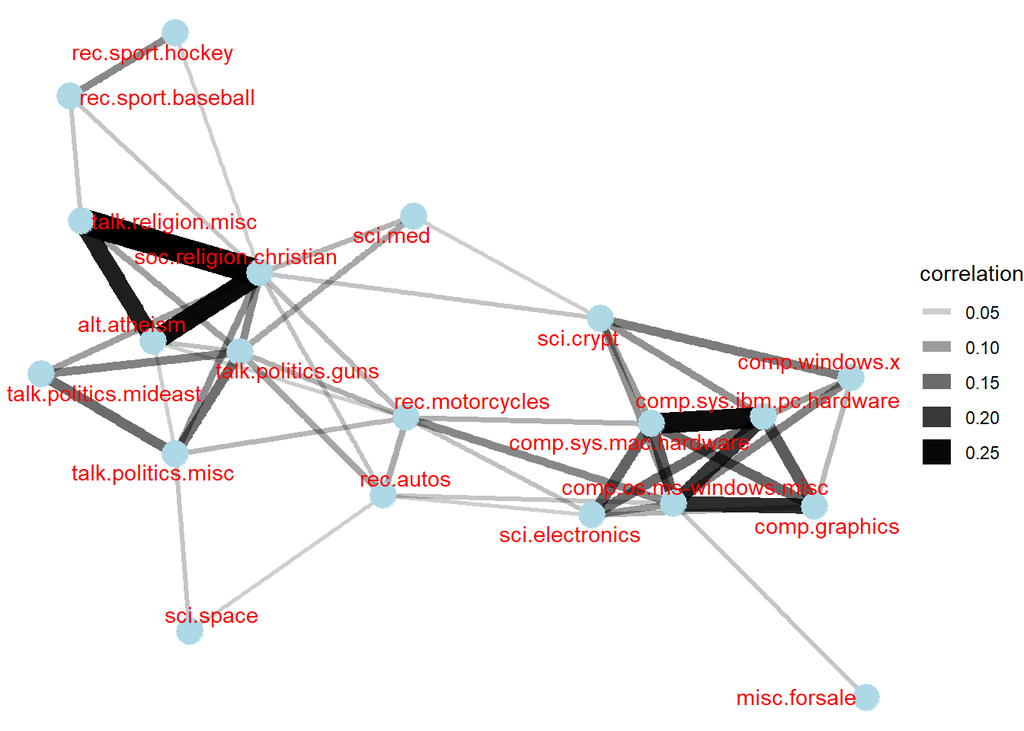

```r
set.seed(2017)

newsgroup_cors %>%
  filter(correlation > .025) %>%
  graph_from_data_frame() %>%
  ggraph(layout = "fr") +
  geom_edge_link(aes(alpha = correlation,
                     width = correlation)) +
  geom_node_point(size = 6,
                  color = "lightblue") +
  geom_node_text(aes(label = name),
                 color = "red",
                 repel = TRUE) +
  theme_void()
```

**(c) n-grams**

**(i) creating n-grams**

In this code chunk below, a bigram and trigram data frames are created by using `unnest_tokens()` of tidytext.

```r
bigrams <- cleaned_text %>%
  unnest_tokens(bigram,
                text,
                token = "ngrams",
                n = 2)

trigrams <- cleaned_text %>%
  unnest_tokens(trigram,
                text,
                token = "ngrams",
                n = 3)

bigrams
```

```
# A tibble: 28,827 × 3
   newsgroup   id    bigram
   <chr>       <chr> <chr>
 1 alt.atheism 54256 <NA>
 2 alt.atheism 54256 <NA>
 3 alt.atheism 54256 as i
 4 alt.atheism 54256 i don't
 5 alt.atheism 54256 don't know
 6 alt.atheism 54256 know this
 7 alt.atheism 54256 this book
 8 alt.atheism 54256 book i
 9 alt.atheism 54256 i will
10 alt.atheism 54256 will use
# ℹ 28,817 more rows
```

```r
trigrams
```

```
# A tibble: 25,929 × 3
   newsgroup   id    trigram
   <chr>       <chr> <chr>
 1 alt.atheism 54256 <NA>
 2 alt.atheism 54256 <NA>
 3 alt.atheism 54256 as i don't
 4 alt.atheism 54256 i don't know
 5 alt.atheism 54256 don't know this
 6 alt.atheism 54256 know this book
 7 alt.atheism 54256 this book i
 8 alt.atheism 54256 book i will
 9 alt.atheism 54256 i will use
10 alt.atheism 54256 will use your
# ℹ 25,919 more rows
```

**(ii) counting n-grams**

##### without stop words filtering

```r
bigrams_count <- bigrams %>%
  filter(bigram != 'NA') %>%
  separate(bigram, c("word1", "word2"), sep = " ") %>%
  filter(!str_detect(word1, "^[0-9]+$"),
         !str_detect(word2, "^[0-9]+$")) %>%
  count(bigram = paste(word1, word2), sort = TRUE)

trigrams_count <- trigrams %>%
  filter(trigram != 'NA') %>%
  separate(trigram, c("word1", "word2", "word3"), sep = " ") %>%
  filter(!str_detect(word1, "^[0-9]+$"),
         !str_detect(word2, "^[0-9]+$"),
         !str_detect(word3, "^[0-9]+$")) %>%
  count(trigram = paste(word1, word2, word3), sort = TRUE)

bigrams_count
```

```
# A tibble: 18,877 × 2
   bigram       n
   <chr>    <int>
 1 of the     169
 2 in the     113
 3 to the      74
 4 to be       59
 5 for the     52
 6 i have      48
 7 that the    47
 8 if you      40
 9 on the      39
10 it is       38
# ℹ 18,867 more rows
```

```r
trigrams_count
```

```
# A tibble: 21,808 × 2
   trigram          n
   <chr>        <int>
 1 i have a        15
 2 one time pad    10
 3 one of the       9
 4 in the bible     7
 5 part of the      7
 6 some of the      7
 7 the end of       7
 8 this is the      7
 9 a lot of         6
10 all of the       6
# ℹ 21,798 more rows
```

##### with stop words filerting

```r
bigrams_count <- bigrams %>%
  filter(bigram != 'NA') %>%
  separate(bigram, c("word1", "word2"), sep = " ") %>%
  filter(!word1 %in% stop_words$word,
         !word2 %in% stop_words$word) %>%
  filter(!str_detect(word1, "^[0-9]+$"),
         !str_detect(word2, "^[0-9]+$")) %>%
  count(bigram = paste(word1, word2), sort = TRUE)

trigrams_count <- trigrams %>%
  filter(trigram != 'NA') %>%
  separate(trigram, c("word1", "word2", "word3"), sep = " ") %>%
  filter(!word1 %in% stop_words$word,
         !word2 %in% stop_words$word,
         !word3 %in% stop_words$word) %>%
  filter(!str_detect(word1, "^[0-9]+$"),
         !str_detect(word2, "^[0-9]+$"),
         !str_detect(word3, "^[0-9]+$")) %>%
  count(trigram = paste(word1, word2, word3), sort = TRUE)
bigrams_count
```

```
# A tibble: 3,384 × 2
   bigram                 n
   <chr>              <int>
 1 static void           10
 2 time pad              10
 3 infield fly            7
 4 vv vv                  6
 5 cock crow              5
 6 noticeshell widget     5
 7 child molestation      4
 8 cock crew              4
 9 gun violence           4
10 heat sink              4
# ℹ 3,374 more rows
```

```r
trigrams_count
```

```
# A tibble: 1,116 × 2
   trigram                          n
   <chr>                        <int>
 1 aberrant behaviors practiced     3
 2 error unknown keysym             3
 3 infield fly rule                 3
 4 message authentication code      3
 5 read write heads                 3
 6 syntax error unknown             3
 7 table syntax error               3
 8 top_level xtwindow top_level     3
 9 translation table syntax         3
10 warning translation table        3
# ℹ 1,106 more rows
```

**(iii) network graphs of n-grams**

The ggraph package is used to plot the bigram and trigram.

##### the chart below has no stop words filtering

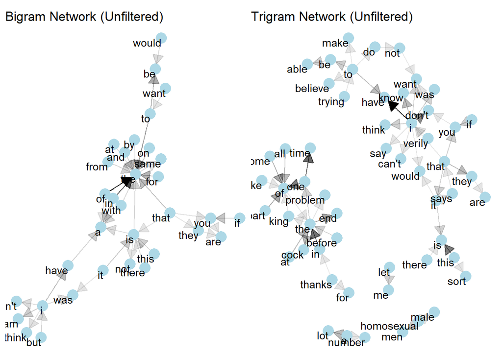

```r
library(igraph)
library(ggraph)
library(patchwork)

# Add these at the top of the unfiltered chunk
set.seed(1234)
a <- grid::arrow(type = "closed", length = unit(.15, "inches"))

# Build unfiltered graphs
bigram_graph_unfiltered <- bigrams %>%
  filter(bigram != 'NA') %>%
  separate(bigram, c("word1", "word2"), sep = " ") %>%
  count(bigram = paste(word1, word2), sort = TRUE) %>%
  separate(bigram, c("word1", "word2"), sep = " ") %>%
  filter(n > 20) %>%
  graph_from_data_frame()

trigram_graph_unfiltered <- trigrams %>%
  filter(trigram != 'NA') %>%
  separate(trigram, c("word1", "word2", "word3"), sep = " ") %>%
  count(trigram = paste(word1, word2, word3), sort = TRUE) %>%
  separate(trigram, c("word1", "word2", "word3"), sep = " ") %>%
  filter(n > 3) %>%   # lower threshold
  graph_from_data_frame()

# Plot
p3 <- ggraph(bigram_graph_unfiltered, layout = "fr") +
  geom_edge_link(aes(edge_alpha = n),
                 show.legend = FALSE,
                 arrow = a,
                 end_cap = circle(.07, 'inches')) +
  geom_node_point(color = "lightblue", size = 5) +
  geom_node_text(aes(label = name), vjust = 1, hjust = 1) +
  theme_void() +
  labs(title = "Bigram Network (Unfiltered)")

p4 <- ggraph(trigram_graph_unfiltered, layout = "fr") +
  geom_edge_link(aes(edge_alpha = n),
                 show.legend = FALSE,
                 arrow = a,
                 end_cap = circle(.07, 'inches')) +
  geom_node_point(color = "lightblue", size = 5) +
  geom_node_text(aes(label = name), vjust = 1, hjust = 1) +
  theme_void() +
  labs(title = "Trigram Network (Unfiltered)")

p3 + p4
```

##### the chart below has stop words filtered off

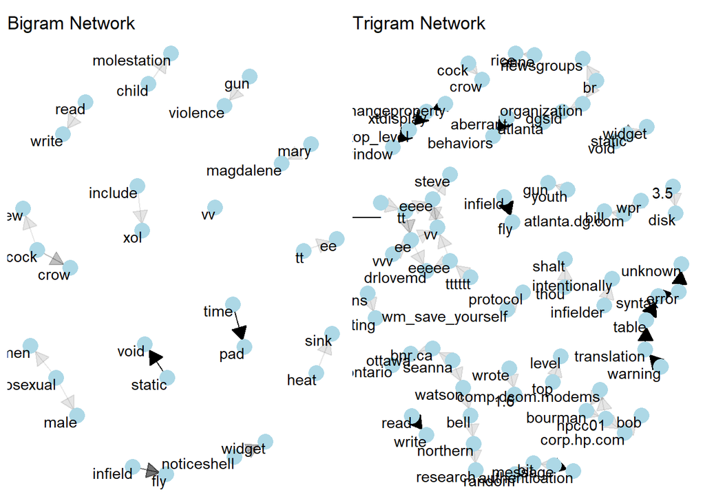

```r
set.seed(1234)
a <- grid::arrow(type = "closed", length = unit(.15, "inches"))

# Build graphs
bigram_graph <- bigrams_count %>%
  separate(bigram, c("word1", "word2"), sep = " ") %>%
  filter(n > 3) %>%   # lower threshold
  graph_from_data_frame()

trigram_graph <- trigrams_count %>%
  separate(trigram, c("word1", "word2", "word3"), sep = " ") %>%
  filter(n > 1) %>%   # lower threshold
  graph_from_data_frame()

# Plot
p1 <- ggraph(bigram_graph, layout = "fr") +
  geom_edge_link(aes(edge_alpha = n),
                 show.legend = FALSE,
                 arrow = a,
                 end_cap = circle(.07, 'inches')) +
  geom_node_point(color = "lightblue", size = 5) +
  geom_node_text(aes(label = name), vjust = 1, hjust = 1) +
  theme_void() +
  labs(title = "Bigram Network")

p2 <- ggraph(trigram_graph, layout = "fr") +
  geom_edge_link(aes(edge_alpha = n),
                 show.legend = FALSE,
                 arrow = a,
                 end_cap = circle(.07, 'inches')) +
  geom_node_point(color = "lightblue", size = 5) +
  geom_node_text(aes(label = name), vjust = 1, hjust = 1) +
  theme_void() +
  labs(title = "Trigram Network")

p1 + p2
```

## 6 References

- [widyr: Widen, process, and re-tidy a dataset](https://cran.r-project.org/web/packages/widyr/vignettes/intro.html)
- [United Nations Voting Correlations](https://cran.r-project.org/web/packages/widyr/vignettes/united_nations.html)